# Analysis Notebook

Trevor Parma

2022-11-02

# Business Task

I will be analyzing Cyclistic historical trip data to answer the following question: How do annual members and casual riders use Cyclistic bikes differently? I will present my findings to the marketing analysis team and will work with them to design marketing strategies to convert casual riders into annual members. Our recommendations will be presented to the director of marketing Lily Moreno and the Cyclistic executive team.

# Preparing the Data

I will be using [Cyclistic trip data](https://divvy-tripdata.s3.amazonaws.com/index.html) made available by [Motivate International Inc.](https://www.motivateco.com/) which is a bike share company in Chicago. I am using the data from October 2021 to September 2022. The license for this data can be found [here](https://ride.divvybikes.com/data-license-agreement).

Data-privacy prevents me from using riders’ identifiable information. This will affect my analysis in the following ways:

1. I won’t be able to see if a casual rider lives in the Cyclistic service area, which could be a big difference between them and members.
2. I won’t be able to see if a casual rider has purchased multiple single passes and will not know the price a casual rider pays versus what a member pays.

Other than that, I will be able to identify all of the differences between members and casual riders.

The data is stored on my computer in this project and in a separate folder so I have a backup.

# Processing the Data

First, I import the data into R Studio. I have chosen to use R for this analysis because I am already very comfortable with programming and R is a powerful tool that I want to familiarize myself with.

```r
# import data
file_names <- list.files(path = "Data/", pattern = ".csv", full.names = TRUE)
tripdata <- do.call(rbind, lapply(file_names, read_csv))
glimpse(tripdata)
```

```
## Rows: 5,828,235
## Columns: 13
## $ ride_id            <chr> "620BC6107255BF4C", "4471C70731AB2E45", "26CA69D43D…
## $ rideable_type      <chr> "electric_bike", "electric_bike", "electric_bike", …
## $ started_at         <dttm> 2021-10-22 12:46:42, 2021-10-21 09:12:37, 2021-10-…
## $ ended_at           <dttm> 2021-10-22 12:49:50, 2021-10-21 09:14:14, 2021-10-…
## $ start_station_name <chr> "Kingsbury St & Kinzie St", NA, NA, NA, NA, NA, NA,…
## $ start_station_id   <chr> "KA1503000043", NA, NA, NA, NA, NA, NA, NA, NA, NA,…
## $ end_station_name   <chr> NA, NA, NA, NA, NA, NA, NA, NA, NA, NA, NA, NA, NA,…
## $ end_station_id     <chr> NA, NA, NA, NA, NA, NA, NA, NA, NA, NA, NA, NA, NA,…
## $ start_lat          <dbl> 41.88919, 41.93000, 41.92000, 41.92000, 41.89000, 4…
## $ start_lng          <dbl> -87.63850, -87.70000, -87.70000, -87.69000, -87.710…
## $ end_lat            <dbl> 41.89000, 41.93000, 41.94000, 41.92000, 41.89000, 4…
## $ end_lng            <dbl> -87.63000, -87.71000, -87.72000, -87.69000, -87.690…
## $ member_casual      <chr> "member", "member", "member", "member", "member", "…
```

I filter out the latitude and longitude columns because they are unnecessary in my analysis.

```r
# remove the unnecessary columns for latitude and longitude
tripdata <- tripdata %>%
  select(-c(start_lat, start_lng, end_lat, end_lng))
```

Currently I can’t aggregate the data well to find differences, so I add columns for the date and its parts, and a column for the weekday.

```r
# add columns for the date, month, day, year, and day of the week of each ride
tripdata$date <- as.Date(tripdata$started_at)
tripdata$month <- format(as.Date(tripdata$date), "%m")
tripdata$day <- format(as.Date(tripdata$date), "%d")
tripdata$year <- format(as.Date(tripdata$date), "%Y")
tripdata$day_of_week <- format(as.Date(tripdata$date), "%A")

# sort days of the week
tripdata$day_of_week <- ordered(tripdata$day_of_week,
                                  levels = c("Sunday", "Monday", "Tuesday", "Wednesday", "Thursday", "Friday", "Saturday"))
```

I add a column for the ride length in seconds because it’s an important difference between members and casual riders.

```r
# add a column for the ride length
tripdata$ride_length <- difftime(tripdata$ended_at, tripdata$started_at)

# change the type of the ride length column to numeric for calculations
tripdata$ride_length <- as.numeric(as.character(tripdata$ride_length))
str(tripdata)
```

```
## tibble [5,828,235 × 15] (S3: tbl_df/tbl/data.frame)
##  $ ride_id           : chr [1:5828235] "620BC6107255BF4C" "4471C70731AB2E45" "26CA69D43D15EE14" "362947F0437E1514" ...
##  $ rideable_type     : chr [1:5828235] "electric_bike" "electric_bike" "electric_bike" "electric_bike" ...
##  $ started_at        : POSIXct[1:5828235], format: "2021-10-22 12:46:42" "2021-10-21 09:12:37" ...
##  $ ended_at          : POSIXct[1:5828235], format: "2021-10-22 12:49:50" "2021-10-21 09:14:14" ...
##  $ start_station_name: chr [1:5828235] "Kingsbury St & Kinzie St" NA NA NA ...
##  $ start_station_id  : chr [1:5828235] "KA1503000043" NA NA NA ...
##  $ end_station_name  : chr [1:5828235] NA NA NA NA ...
##  $ end_station_id    : chr [1:5828235] NA NA NA NA ...
##  $ member_casual     : chr [1:5828235] "member" "member" "member" "member" ...
##  $ date              : Date[1:5828235], format: "2021-10-22" "2021-10-21" ...
##  $ month             : chr [1:5828235] "10" "10" "10" "10" ...
##  $ day               : chr [1:5828235] "22" "21" "16" "16" ...
##  $ year              : chr [1:5828235] "2021" "2021" "2021" "2021" ...
##  $ day_of_week       : Ord.factor w/ 7 levels "Sunday"<"Monday"<..: 6 5 7 7 4 5 5 4 5 4 ...
##  $ ride_length       : num [1:5828235] 188 97 467 75 496 861 161 501 448 509 ...
```

I finalize the data by removing instances where the ride length is negative because that is an error in the data. I put this into a new dataframe because I am removing data.

```r
# ride length shouldn't be negative, so I make sure there aren't any instances of that
tripdata_2 <- tripdata[!(tripdata$ride_length < 0),]
```

# Analyzing the data

I create a descriptive analysis on the ride lengths, finding the mean, median, maximum, and minimum for the value.

```r
# descriptive analysis on ride_length
mean(tripdata_2$ride_length)
```

```
## [1] 1176.281
```

```r
median(tripdata_2$ride_length)
```

```
## [1] 629
```

```r
max(tripdata_2$ride_length)
```

```
## [1] 2442301
```

```r
min(tripdata_2$ride_length)
```

```
## [1] 0
```

I do the same analysis as above, but this time I look at how the length differs between members and casual riders.

```r
# compare members and casual riders
aggregate(tripdata_2$ride_length ~ tripdata_2$member_casual, FUN = mean)
```

```
##   tripdata_2$member_casual tripdata_2$ride_length
## 1                   casual              1761.6450
## 2                   member               766.1175
```

```r
aggregate(tripdata_2$ride_length ~ tripdata_2$member_casual, FUN = median)
```

```
##   tripdata_2$member_casual tripdata_2$ride_length
## 1                   casual                    807
## 2                   member                    533
```

```r
aggregate(tripdata_2$ride_length ~ tripdata_2$member_casual, FUN = max)
```

```
##   tripdata_2$member_casual tripdata_2$ride_length
## 1                   casual                2442301
## 2                   member                  93594
```

```r
aggregate(tripdata_2$ride_length ~ tripdata_2$member_casual, FUN = min)
```

```
##   tripdata_2$member_casual tripdata_2$ride_length
## 1                   casual                      0
## 2                   member                      0
```

You can immediately see that casual members are spending more time with the bikes rented out.  
After this I found the average ride length of members and casual riders by the day of the week.

```r
# average ride length by each day for members vs casual users
aggregate(tripdata_2$ride_length ~ tripdata_2$member_casual + tripdata_2$day_of_week, FUN = mean)
```

```
##    tripdata_2$member_casual tripdata_2$day_of_week tripdata_2$ride_length
## 1                    casual                 Sunday              2061.8737
## 2                    member                 Sunday               852.8695
## 3                    casual                 Monday              1783.7004
## 4                    member                 Monday               739.6565
## 5                    casual                Tuesday              1548.5476
## 6                    member                Tuesday               729.7824
## 7                    casual              Wednesday              1502.0471
## 8                    member              Wednesday               727.3683
## 9                    casual               Thursday              1540.7802
## 10                   member               Thursday               737.6436
## 11                   casual                 Friday              1680.6606
## 12                   member                 Friday               751.7054
## 13                   casual               Saturday              1962.5317
## 14                   member               Saturday               855.8207
```

I took this a step further and found ridership data by the rider type and weekday.

```r
# analyze ridership data by type and weekday
tripdata_2 %>%
  mutate(weekday = wday(started_at)) %>%
  group_by(member_casual, weekday) %>%
  summarise(number_of_rides = n(), average_duration = mean(ride_length)) %>%
  arrange(member_casual, weekday)
```

```
## # A tibble: 14 × 4
## # Groups:   member_casual [2]
##    member_casual weekday number_of_rides average_duration
##    <chr>           <int>           <int>            <dbl>
##  1 casual              1          405009            2062.
##  2 casual              2          279785            1784.
##  3 casual              3          275772            1549.
##  4 casual              4          281660            1502.
##  5 casual              5          306691            1541.
##  6 casual              6          352508            1681.
##  7 casual              7          499801            1963.
##  8 member              1          393601             853.
##  9 member              2          473059             740.
## 10 member              3          541519             730.
## 11 member              4          538488             727.
## 12 member              5          530547             738.
## 13 member              6          491465             752.
## 14 member              7          458222             856.
```

I created a visual of the number of rides to compare members and casual riders.

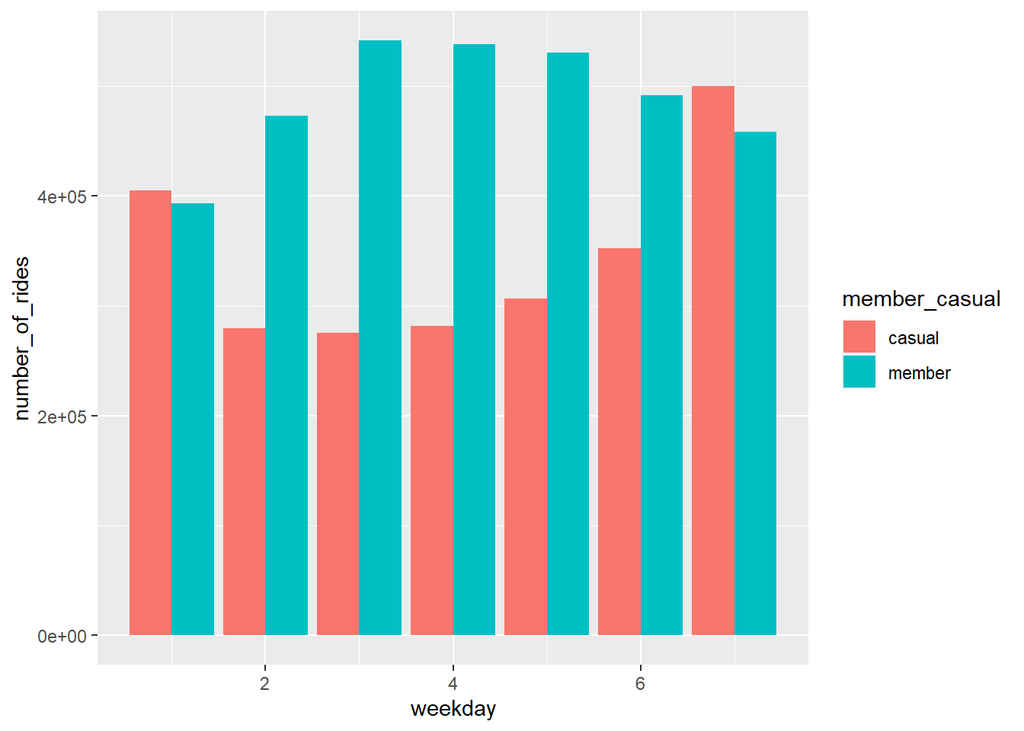

```r
# visualize the number of rides by rider type
tripdata_2 %>%
  mutate(weekday = wday(started_at)) %>%
  group_by(member_casual, weekday) %>%
  summarise(number_of_rides = n(), average_duration = mean(ride_length)) %>%
  arrange(member_casual, weekday) %>%
  ggplot(aes(x = weekday, y = number_of_rides, fill = member_casual)) +
  geom_col(position = "dodge")
```

Finally, I created a visualization to see the average duration of rides between members and casual riders.

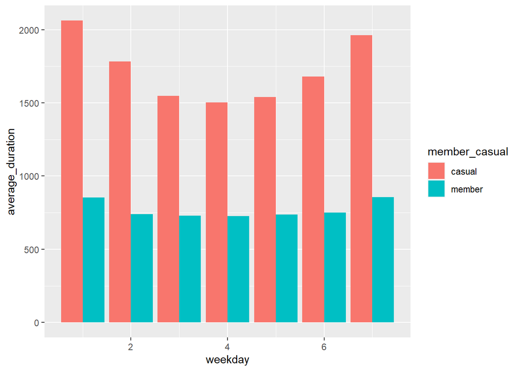

```r
# visualize average duration
tripdata_2 %>%
  mutate(weekday = wday(started_at)) %>%
  group_by(member_casual, weekday) %>%
  summarise(number_of_rides = n(), average_duration = mean(ride_length)) %>%
  arrange(member_casual, weekday) %>%
  ggplot(aes(x = weekday, y = average_duration, fill = member_casual)) +
  geom_col(position = "dodge")
```